# Chapter 6

Paul Lassmann-Klee

2018-12-09

# Implement the analyses of Chapter 8 of MABS using the RATS data.

The dataset used for this exercise is nutrition data aqcuired from three different groups of rats (Crowder and Hand, 1990). The rats were given three different nutritional regimes and weight was repeatedly measured. Measurements were made weekly and over a period of 9 weeks. First we shall plot the individual responses, i.e., weight measurements and their changes in time for the three different diet groups.

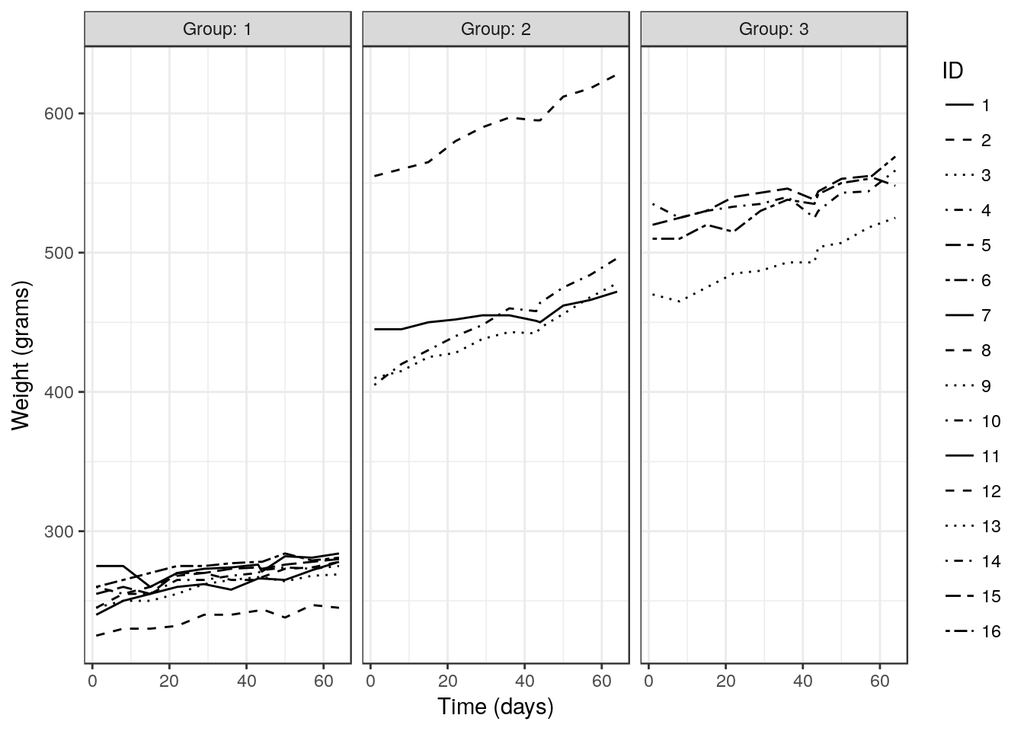

We can see that there seems to be a difference between the groups, group 1 having lower Weight as Group 2 and 3, but we have to find out if these differences are significant. Also the Weight seems to increase with time. First we have to standardise the Weight values, since we want to take into account the individuals who have already high weight and track them.

Now we will plot the previous plot again, but using the standardised weight.

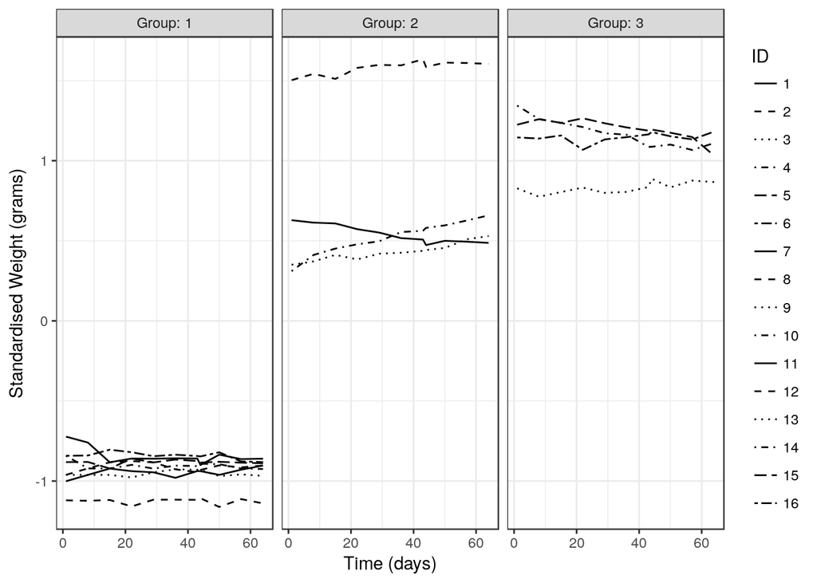

Note that now weight in groups 2 and 3 do not seem to increase with time as in the unstandardised plot.

Perhaps a summary graphical overview can give us a better insight into the changes of weight in time between groups.

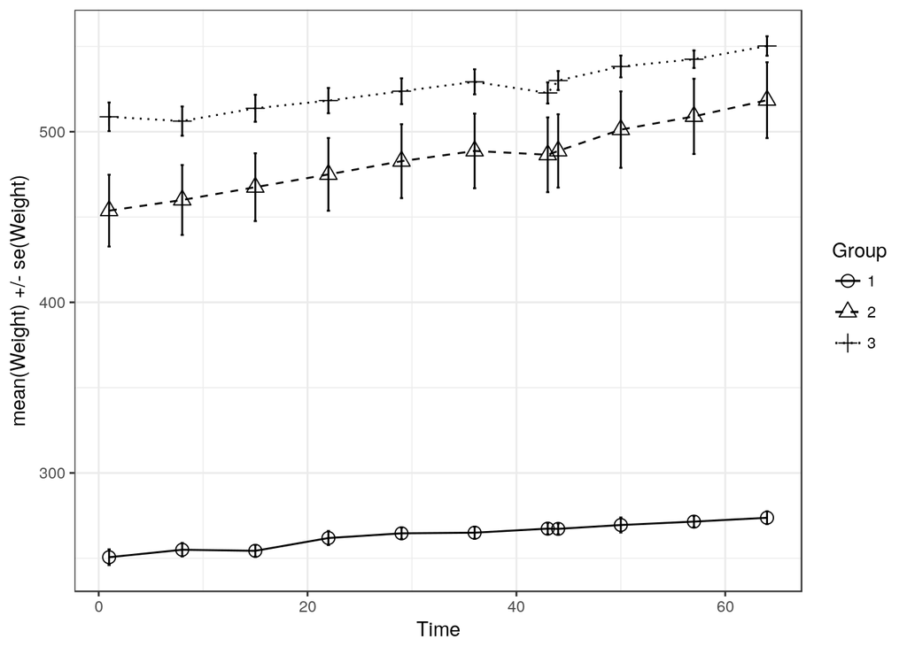

We see more clearly now, that there are difference between the groups of rats, how should we able to better interpret the changes? We can apply a summary measure, in this case would be the overall mean, since we have equal time intervals. To visualise the means, we can use boxplots.

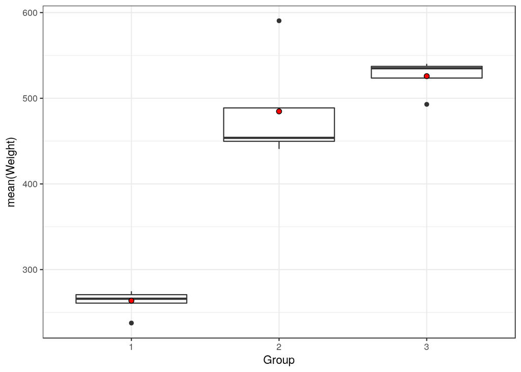

We can see differences in the mean during the observed time. We observe some outliers, which we could remove later. Since we have three groups, we cannot perform a Students t-test to compare the differences in mean, but we can use for this purpose a ANOVA test

Analysis of Variance Model

|  | Df | Sum Sq | Mean Sq | F value | Pr(>F) |
| --- | --- | --- | --- | --- | --- |
| **Group** | 2 | 236732 | 118366 | 88 | 2.8e-08 |
| **Residuals** | 13 | 17471 | 1344 | NA | NA |

We observe a statistically significant difference in mean Weight between the groups.

# Implement the analyses of Chapter 9 of MABS using the BPRS data.

The BPRS data used is an assessment of a Brief psychiatric rate scale in 40 male participants assigned randomly to two treatment groups and assessed in weekly intervals during eight weeks. The rating scale instrument is used to evaluate patients with suspect of schizophrenia.

First we plot the data to analyse it visually.

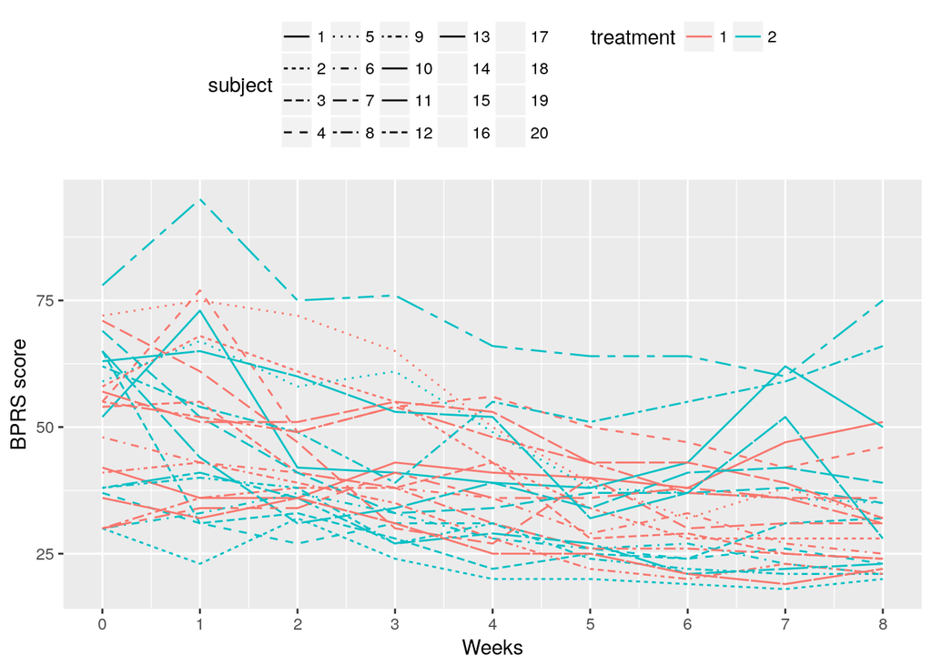

We observe no marked differences between the treatments ( different colours). First we can create a simple linear regression model of the BPRS score and the time in weeks and treatment groups

Fitting linear model: bprs ~ week + treatment

|  | Estimate | Std. Error | t value | Pr(>\|t\|) |
| --- | --- | --- | --- | --- |
| **(Intercept)** | 46 | 1.4 | 34 | 6.3e-114 |
| **week** | -2.3 | 0.25 | -9 | 1.4e-17 |
| **treatment2** | 0.57 | 1.3 | 0.44 | 0.66 |

We observe that the weeks affect significantly the BPRS score, for each week of treatment the score drops ca. -2. There is no significant difference between the treatments.

This model does not take into account that the measurements are dependent of each other, depending on the time in weeks. A better estimate can be obtained with a mixed model with a random intercept. This model applies random intercepts depending on the subjects and the subjects are treated as a random effect. The time and the group are fixed.

# *Mixed model with random intercepts*

|  | *Dependent variable:* |
| --- | --- |
|  | bprs |
| week | -2.270*** |
|  | (0.208) |
| treatment2 | 0.572 |
|  | (1.076) |
| Constant | 46.454*** |
|  | (1.909) |
| Observations | 360 |
| Log Likelihood | -1,369.356 |
| Akaike Inf. Crit. | 2,748.712 |
| Bayesian Inf. Crit. | 2,768.143 |
| *Note:* | p<0.1; p<0.05; p<0.01 |

If observing carefully both the linear and the mixed model gives us similar results for the fixed effects. Here nor shown are the variance of the subjects 47.41 with a standard deviation of 6.885.

We can add random slopes to the model and evaluate if we get a better fit.

# *Mixed model with random slopes and intercepts*

|  | *Dependent variable:* |
| --- | --- |
|  | bprs |
| week | -2.270*** |
|  | (0.298) |
| treatment2 | 0.572 |
|  | (1.040) |
| Constant | 46.454*** |
|  | (2.105) |
| Observations | 360 |
| Log Likelihood | -1,365.720 |
| Akaike Inf. Crit. | 2,745.440 |
| Bayesian Inf. Crit. | 2,772.643 |
| *Note:* | p<0.1; p<0.05; p<0.01 |

# *Compare the mixed models*

| Statistic | N | Mean | St. Dev. | Min | Pctl(25) | Pctl(75) | Max |
| --- | --- | --- | --- | --- | --- | --- | --- |
| Df | 2 | 6.000 | 1.414 | 5 | 5.5 | 6.5 | 7 |
| AIC | 2 | 2,747.076 | 2.314 | 2,745.440 | 2,746.258 | 2,747.894 | 2,748.712 |
| BIC | 2 | 2,770.393 | 3.182 | 2,768.143 | 2,769.268 | 2,771.518 | 2,772.643 |
| logLik | 2 | -1,367.538 | 2.571 | -1,369.356 | -1,368.447 | -1,366.629 | -1,365.720 |
| deviance | 2 | 2,735.076 | 5.142 | 2,731.440 | 2,733.258 | 2,736.894 | 2,738.712 |
| Chisq | 1 | 7.272 |  | 7.272 | 7.272 | 7.272 | 7.272 |
| Chi Df | 1 | 2.000 |  | 2.000 | 2.000 | 2.000 | 2.000 |
| Pr(> Chisq) | 1 | 0.026 |  | 0.026 | 0.026 | 0.026 | 0.026 |

The mixed model with random slopes and random intercepts fits the data better.

Finally, we can fit a random intercept and slope model that allows for a group × time interaction

# *Compare the model with an interaction*

| Statistic | N | Mean | St. Dev. | Min | Pctl(25) | Pctl(75) | Max |
| --- | --- | --- | --- | --- | --- | --- | --- |
| Df | 2 | 7.500 | 0.707 | 7 | 7.2 | 7.8 | 8 |
| AIC | 2 | 2,744.855 | 0.828 | 2,744.269 | 2,744.562 | 2,745.148 | 2,745.440 |
| BIC | 2 | 2,774.001 | 1.920 | 2,772.643 | 2,773.322 | 2,774.679 | 2,775.358 |
| logLik | 2 | -1,364.927 | 1.121 | -1,365.720 | -1,365.324 | -1,364.531 | -1,364.135 |
| deviance | 2 | 2,729.855 | 2.242 | 2,728.269 | 2,729.062 | 2,730.648 | 2,731.440 |
| Chisq | 1 | 3.171 |  | 3.171 | 3.171 | 3.171 | 3.171 |
| Chi Df | 1 | 1.000 |  | 1.000 | 1.000 | 1.000 | 1.000 |
| Pr(> Chisq) | 1 | 0.075 |  | 0.075 | 0.075 | 0.075 | 0.075 |

The model with an interaction with time and treatment group fits slightly better the data, but the difference is not significant. We can plot the fitted values

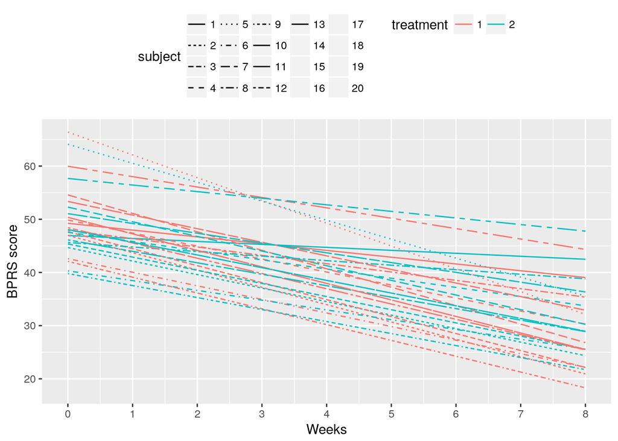

The plot shows clearly how the duration of the treatment in weeks lowers the score and this in a statistically significant way. There are no significant differences between the treatment groups.